# Chicago Bulls Analysis

Jingjing Tang

2023-05-05

## 1. Introduction

#### Scenario

As a data analyst for the Chicago Bulls in the NBA, the task at hand is to find the best five starting players within the team’s budget of $118 million for the upcoming 2019-20 season. The team’s poor performance in the previous season, ranking 27th out of 30 based on win-loss record, makes this task particularly important. Additionally, Chicago Bulls team budget ranks 26th out of 30, with the highest payroll budget, Portland, having $148 million and the best-performing team, Milwaukee Bucks, having a payroll budget of $131 million in the previous season.

#### Relevant background of basketball

The team, Chicago Bulls are a professional basketball team based in Chicago and they compete in the NBA (National Basketball Association), which is the premier professional basketball league in North America and one of the most popular and prestigious basketball leagues in the world. Chicago Bulls ranked 27th out of 30 during 2018-19 season, which is not an ideal result.

In basketball, there are five positions on a team: point guard, shooting guard, small forward, power forward, and center. The following list outlines each position and its specific roles and responsibilities.

1. Point Guard (PG): The point guard is usually the team’s primary ball-handler and playmaker. They are responsible for bringing the ball up the court, setting up offensive plays, and distributing the ball to their teammates. A good point guard is often characterised by their assists (number of passes leading directly to a basket), steals (number of times they take the ball from an opposing player), turnovers and their ability to be a scoring threat (3-points percentages)$^{1}$.
2. Shooting Guard (SG): The shooting guard’s primary role is to score points by shooting the ball from the outside and driving to the basket. A good shooting guard is often characterised by their shooting percentages (field goal percentage, three-point percentage, free throw percentage, effective field goal percentage).
3. Small Forward (SF): The small forward is a all-around position that requires a combination of skills, including shooting and defending. They often play a role as a secondary ball handler and are required to have good dribbling skills. A good small forward is often characterised by their all-around statistics, including shooting percentages (2-points percentage), rebounds, and steals$^{2}$.
4. Power Forward (PF): The power forward is typically the most physical and aggressive player who plays close to the basket. They are responsible for securing rebounds and keeping possession. Therefore, a good power forward is often characterised by their defensive statistics (Offensive Rebounds, Defensive Rebounds, Blocks)$^{3}$.
5. Center (C): The center is typically the tallest player on the team and plays close to the basket. They are responsible for defending the basket, scoring points in the paint, blocking shots, and grabbing rebounds. A good center is often characterised by their rebounding (total rebounds), blocks and shooting percentage (2-points percentage).

The maximum roster size in the NBA is 15 players, with a minimum of 13 players required during the regular season. Each team should have 5 players on the court during a game and an additional 8 players available on the bench. This means 12 of the players on the roster can be active on a game day, while the remaining 3 players on the roster are typically inactive and serve as backups in case of injury or other emergencies$^{4}$.

#### Project aim

The project aims to use data analysis and visualization techniques to identify players across the NBA league, that can provide the highest value for Chicago Bulls within the salary cap. Ultimately, the goal of this project is to enhance the team’s performance and future success in the upcoming season.

#### Justification and importance

The importance of this project lies in its ability to provide data-driven insights and decision makings for player selection that can positively impact the team’s overall performance and success. This project should also assist with optimise the team’s budget and ensure that the funds are utilised properly.

## 2. Reading and cleaning the raw data

#### Load data into R

In this section, all 5 datasets are imported into R.

- `2018-19_nba_player-salaries.csv` includes the salary information of individual players in the NBA for the 2018-19 season. It is saved in the dataframe called `salary`.
- `2018-19_nba_player-statistics.csv` provides comprehensive statistical information for each NBA player throughout the 2018-19 season. It is saved in the dataframe called `player_stats`.
- `2018-19_nba_team-statistics_1.csv` includes various team statistics for in the NBA for the 2018-19 season. It is saved in the dataframe called `team_stat_1`.
- `2018-19_nba_team-statistics_2.csv` includes comprehensive team statistics for the NBA’s 2018-19 season. It is saved in the dataframe called `team_stat_2`.
- `2019-20_nba_team-payroll.csv`includes the team’s budget for payroll during the 2019-20 NBA season. It is saved in the dataframe called `payroll`.

More details of these datasets, which includes variables descriptions, can be found through [the link](https://uclearn.canberra.edu.au/courses/13262/pages/data-description-reproducible-data-analysis-project).

```r
salary <- read.csv("project-data/raw/2018-19_nba_player-salaries.csv")
player_stats <- read.csv("project-data/raw/2018-19_nba_player-statistics.csv")
team_stat_1 <- read.csv("project-data/raw/2018-19_nba_team-statistics_1.csv")
team_stat_2 <- read.csv("project-data/raw/2018-19_nba_team-statistics_2.csv")
payroll <- read.csv("project-data/raw/2019-20_nba_team-payroll.csv")
```

#### Understand data

In this section, each code chunk will check the structure of the data frames, and check the summary information of the data frames.

- salary

  `salary` contains 576 observations and 3 variables. There is no missing values in this dataframe.

```r
str(salary)
```

```
## 'data.frame':    576 obs. of  3 variables:
##  $ player_id  : int  1 2 3 4 5 6 7 8 9 10 ...
##  $ player_name: chr  "Alex Abrines" "Quincy Acy" "Steven Adams" "Jaylen Adams" ...
##  $ salary     : int  3667645 213948 24157304 236854 2955840 77250 5285394 77250 2000000 22347015 ...
```

```r
summary(salary)
```

```
##    player_id     player_name            salary
##  Min.   :  1.0   Length:576         Min.   :   47370
##  1st Qu.:144.8   Class :character   1st Qu.: 1349383
##  Median :288.5   Mode  :character   Median : 2530560
##  Mean   :288.5                      Mean   : 6258149
##  3rd Qu.:432.2                      3rd Qu.: 9000000
##  Max.   :576.0                      Max.   :37457154
```

- player_stats

```r
str(player_stats)
```

```
## 'data.frame':    708 obs. of  29 variables:
##  $ player_name: chr  "Alex Abrines" "Quincy Acy" "Jaylen Adams" "Steven Adams" ...
##  $ Pos        : chr  "SG" "PF" "PG" "C" ...
##  $ Age        : int  25 28 22 25 21 21 25 33 21 23 ...
##  $ Tm         : chr  "OKC" "PHO" "ATL" "OKC" ...
##  $ G          : int  31 10 34 80 82 19 7 81 10 38 ...
##  $ GS         : int  2 0 1 80 28 3 0 81 1 2 ...
##  $ MP         : int  588 123 428 2669 1913 194 22 2687 120 416 ...
##  $ FG         : int  56 4 38 481 280 11 3 684 13 67 ...
##  $ FGA        : int  157 18 110 809 486 36 10 1319 39 178 ...
##  $ FG.        : num  0.357 0.222 0.345 0.595 0.576 0.306 0.3 0.519 0.333 0.376 ...
##  $ X3P        : int  41 2 25 0 3 6 0 10 3 32 ...
##  $ X3PA       : int  127 15 74 2 15 23 4 42 12 99 ...
##  $ X3P.       : num  0.323 0.133 0.338 0 0.2 0.261 0 0.238 0.25 0.323 ...
##  $ X2P        : int  15 2 13 481 277 5 3 674 10 35 ...
##  $ X2PA       : int  30 3 36 807 471 13 6 1277 27 79 ...
##  $ X2P.       : num  0.5 0.667 0.361 0.596 0.588 0.385 0.5 0.528 0.37 0.443 ...
##  $ eFG.       : num  0.487 0.278 0.459 0.595 0.579 0.389 0.3 0.522 0.372 0.466 ...
##  $ FT         : int  12 7 7 146 166 4 1 349 8 45 ...
##  $ FTA        : int  13 10 9 292 226 4 2 412 12 60 ...
##  $ FT.        : num  0.923 0.7 0.778 0.5 0.735 1 0.5 0.847 0.667 0.75 ...
##  $ ORB        : int  5 3 11 391 165 3 1 251 11 3 ...
##  $ DRB        : int  43 22 49 369 432 16 3 493 15 20 ...
##  $ TRB        : int  48 25 60 760 597 19 4 744 26 23 ...
##  $ AST        : int  20 8 65 124 184 5 6 194 13 25 ...
##  $ STL        : int  17 1 14 117 71 1 2 43 1 6 ...
##  $ BLK        : int  6 4 5 76 65 4 0 107 0 6 ...
##  $ TOV        : int  14 4 28 135 121 6 2 144 8 33 ...
##  $ PF         : int  53 24 45 204 203 13 4 179 7 47 ...
##  $ PTS        : int  165 17 108 1108 729 32 7 1727 37 211 ...
```

```r
summary(player_stats)
```

```
##  player_name            Pos                 Age             Tm
##  Length:708         Length:708         Min.   :19.00   Length:708
##  Class :character   Class :character   1st Qu.:23.00   Class :character
##  Mode  :character   Mode  :character   Median :26.00   Mode  :character
##                                        Mean   :26.14
##                                        3rd Qu.:29.00
##                                        Max.   :42.00
##
##        G               GS              MP               FG
##  Min.   : 1.00   Min.   : 0.00   Min.   :   1.0   Min.   :  0.0
##  1st Qu.:19.00   1st Qu.: 0.00   1st Qu.: 245.2   1st Qu.: 32.0
##  Median :44.00   Median : 6.00   Median : 788.0   Median :108.5
##  Mean   :42.88   Mean   :19.85   Mean   : 972.3   Mean   :162.6
##  3rd Qu.:68.00   3rd Qu.:32.00   3rd Qu.:1579.5   3rd Qu.:236.2
##  Max.   :82.00   Max.   :82.00   Max.   :3028.0   Max.   :843.0
##
##       FGA               FG.              X3P              X3PA
##  Min.   :   0.00   Min.   :0.0000   Min.   :  0.00   Min.   :   0.0
##  1st Qu.:  72.75   1st Qu.:0.4000   1st Qu.:  4.00   1st Qu.:  13.0
##  Median : 256.00   Median :0.4340   Median : 26.00   Median :  79.0
##  Mean   : 355.42   Mean   :0.4373   Mean   : 46.12   Mean   : 130.1
##  3rd Qu.: 526.00   3rd Qu.:0.4850   3rd Qu.: 69.25   3rd Qu.: 200.0
##  Max.   :1909.00   Max.   :1.0000   Max.   :378.00   Max.   :1028.0
##                    NA's   :6
##       X3P.            X2P             X2PA             X2P.
##  Min.   :0.000   Min.   :  0.0   Min.   :   0.0   Min.   :0.0000
##  1st Qu.:0.286   1st Qu.: 18.0   1st Qu.:  40.0   1st Qu.:0.4500
##  Median :0.335   Median : 71.0   Median : 138.0   Median :0.5000
##  Mean   :0.315   Mean   :116.5   Mean   : 225.3   Mean   :0.4923
##  3rd Qu.:0.372   3rd Qu.:164.2   3rd Qu.: 314.5   3rd Qu.:0.5480
##  Max.   :1.000   Max.   :674.0   Max.   :1277.0   Max.   :1.0000
##  NA's   :47                                       NA's   :15
##       eFG.              FT              FTA              FT.
##  Min.   :0.0000   Min.   :  0.00   Min.   :  0.00   Min.   :0.0000
##  1st Qu.:0.4700   1st Qu.: 11.00   1st Qu.: 15.00   1st Qu.:0.6840
##  Median :0.5080   Median : 39.00   Median : 51.00   Median :0.7630
##  Mean   :0.5002   Mean   : 69.88   Mean   : 91.01   Mean   :0.7396
##  3rd Qu.:0.5517   3rd Qu.: 94.00   3rd Qu.:123.00   3rd Qu.:0.8250
##  Max.   :1.5000   Max.   :754.00   Max.   :858.00   Max.   :1.0000
##  NA's   :6                                          NA's   :43
```

[output cut: 9 more lines]

```
##  Min.   :  0.00   Min.   :  0.00   Min.   :  0.00   Min.   :  0.0
##  1st Qu.:  7.00   1st Qu.:  3.00   1st Qu.: 11.00   1st Qu.: 24.0
##  Median : 21.00   Median : 10.00   Median : 36.00   Median : 73.5
##  Mean   : 30.58   Mean   : 19.29   Mean   : 53.52   Mean   : 84.1
##  3rd Qu.: 46.00   3rd Qu.: 25.00   3rd Qu.: 75.00   3rd Qu.:131.2
##  Max.   :170.00   Max.   :199.00   Max.   :387.00   Max.   :292.0
##
##       PTS
##  Min.   :   0.00
##  1st Qu.:  82.75
##  Median : 294.00
##  Mean   : 441.29
##  3rd Qu.: 634.00
##  Max.   :2818.00
##
```

- team_stat_1

  `team_stat_1` dataframe contains 30 observations and 25 variables. 3 columns with missing values were found, which does not contain any data.

```r
str(team_stat_1)
```

```
## 'data.frame':    30 obs. of  25 variables:
##  $ Rk    : int  1 2 3 4 5 6 7 8 9 10 ...
##  $ Team  : chr  "Milwaukee Bucks" "Golden State Warriors" "Toronto Raptors" "Utah Jazz" ...
##  $ Age   : num  26.9 28.4 27.3 27.3 29.2 26.2 24.9 25.7 25.7 27 ...
##  $ W     : int  60 57 58 50 53 53 54 49 49 48 ...
##  $ L     : int  22 25 24 32 29 29 28 33 33 34 ...
##  $ PW    : int  61 56 56 54 53 51 51 52 50 50 ...
##  $ PL    : int  21 26 26 28 29 31 31 30 32 32 ...
##  $ MOV   : num  8.87 6.46 6.09 5.26 4.77 4.2 3.95 4.44 3.4 3.33 ...
##  $ SOS   : num  -0.82 -0.04 -0.6 0.03 0.19 0.24 0.24 -0.54 0.15 -0.57 ...
##  $ SRS   : num  8.04 6.42 5.49 5.28 4.96 4.43 4.19 3.9 3.56 2.76 ...
##  $ ORtg  : num  114 116 113 111 116 ...
##  $ DRtg  : num  105 110 107 106 111 ...
##  $ NRtg  : num  8.6 6.4 6 5.2 4.8 4.2 4.1 4.4 3.3 3.4 ...
##  $ Pace  : num  103.3 100.9 100.2 100.3 97.9 ...
##  $ FTr   : num  0.255 0.227 0.247 0.295 0.279 0.258 0.232 0.215 0.266 0.242 ...
##  $ X3PAr : num  0.419 0.384 0.379 0.394 0.519 0.339 0.348 0.381 0.347 0.292 ...
##  $ TS.   : num  0.583 0.596 0.579 0.572 0.581 0.568 0.558 0.567 0.545 0.561 ...
##  $ eFG.  : num  0.55 0.565 0.543 0.538 0.542 0.528 0.527 0.534 0.514 0.53 ...
##  $ TOV.  : num  12 12.6 12.4 13.4 12 12.1 11.9 11.5 11.7 12.4 ...
##  $ ORB.  : num  20.8 22.5 21.9 22.9 22.8 26.6 26.6 21.6 26 21.9 ...
##  $ FT.FGA: num  0.197 0.182 0.198 0.217 0.221 0.21 0.175 0.173 0.19 0.182 ...
##  $ DRB.  : num  80.3 77.1 77.1 80.3 74.4 77.9 78 77 78.2 76.2 ...
##  $ X     : logi  NA NA NA NA NA NA ...
##  $ X.1   : logi  NA NA NA NA NA NA ...
##  $ X.2   : logi  NA NA NA NA NA NA ...
```

```r
summary(team_stat_1)
```

```
##        Rk            Team                Age              W
##  Min.   : 1.00   Length:30          Min.   :23.40   Min.   :17.00
##  1st Qu.: 8.25   Class :character   1st Qu.:25.48   1st Qu.:33.00
##  Median :15.50   Mode  :character   Median :26.30   Median :41.50
##  Mean   :15.50                      Mean   :26.28   Mean   :41.00
##  3rd Qu.:22.75                      3rd Qu.:27.00   3rd Qu.:49.75
##  Max.   :30.00                      Max.   :29.20   Max.   :60.00
##        L               PW              PL             MOV
##  Min.   :22.00   Min.   :19.00   Min.   :21.00   Min.   :-9.610
##  1st Qu.:32.25   1st Qu.:37.00   1st Qu.:31.25   1st Qu.:-1.665
##  Median :40.50   Median :40.50   Median :41.50   Median :-0.150
##  Mean   :41.00   Mean   :41.10   Mean   :40.90   Mean   : 0.001
##  3rd Qu.:49.00   3rd Qu.:50.75   3rd Qu.:45.00   3rd Qu.: 3.812
##  Max.   :65.00   Max.   :61.00   Max.   :63.00   Max.   : 8.870
##       SOS              SRS                 ORtg            DRtg
##  Min.   :-0.820   Min.   :-9.390000   Min.   :104.5   Min.   :105.2
##  1st Qu.:-0.325   1st Qu.:-1.327500   1st Qu.:108.3   1st Qu.:108.3
##  Median : 0.110   Median :-0.425000   Median :110.7   Median :110.2
##  Mean   :-0.003   Mean   :-0.003333   Mean   :110.4   Mean   :110.4
##  3rd Qu.: 0.240   3rd Qu.: 3.815000   3rd Qu.:112.5   3rd Qu.:112.6
##  Max.   : 0.730   Max.   : 8.040000   Max.   :115.9   Max.   :117.6
##       NRtg                Pace             FTr             X3PAr
##  Min.   :-9.900000   Min.   : 96.60   Min.   :0.2150   Min.   :0.2860
##  1st Qu.:-1.650000   1st Qu.: 98.22   1st Qu.:0.2425   1st Qu.:0.3325
##  Median :-0.150000   Median : 99.90   Median :0.2570   Median :0.3475
##  Mean   :-0.003333   Mean   :100.04   Mean   :0.2588   Mean   :0.3588
##  3rd Qu.: 3.925000   3rd Qu.:101.55   3rd Qu.:0.2692   3rd Qu.:0.3832
##  Max.   : 8.600000   Max.   :103.90   Max.   :0.3260   Max.   :0.5190
##       TS.              eFG.             TOV.            ORB.
##  Min.   :0.5290   Min.   :0.4900   Min.   :10.90   Min.   :19.40
##  1st Qu.:0.5505   1st Qu.:0.5140   1st Qu.:11.93   1st Qu.:21.75
##  Median :0.5555   Median :0.5255   Median :12.40   Median :22.60
##  Mean   :0.5596   Mean   :0.5242   Mean   :12.40   Mean   :22.89
##  3rd Qu.:0.5710   3rd Qu.:0.5317   3rd Qu.:12.85   3rd Qu.:24.40
##  Max.   :0.5960   Max.   :0.5650   Max.   :14.30   Max.   :26.60
##      FT.FGA            DRB.          X             X.1            X.2
##  Min.   :0.1680   Min.   :72.50   Mode:logical   Mode:logical   Mode:logical
##  1st Qu.:0.1825   1st Qu.:76.25   NA's:30        NA's:30        NA's:30
##  Median :0.1960   Median :77.10
##  Mean   :0.1983   Mean   :77.07
##  3rd Qu.:0.2100   3rd Qu.:77.97
##  Max.   :0.2580   Max.   :80.30
```

- team_stat_2

  `team_stat_2` dataframe contains 30 observations and 25 variables. No missing values were found in this dataframe.

```r
str(team_stat_2)
```

```
## 'data.frame':    30 obs. of  25 variables:
##  $ Rk  : int  1 2 3 4 5 6 7 8 9 10 ...
##  $ Team: chr  "Milwaukee Bucks" "Golden State Warriors" "New Orleans Pelicans" "Philadelphia 76ers" ...
##  $ G   : int  82 82 82 82 82 82 82 82 82 82 ...
##  $ MP  : int  19780 19805 19755 19805 19830 19855 19855 19880 19730 19930 ...
##  $ FG  : int  3555 3612 3581 3407 3384 3470 3497 3460 3541 3456 ...
##  $ FGA : int  7471 7361 7563 7233 7178 7427 7706 7305 7637 7387 ...
##  $ FG. : num  0.476 0.491 0.473 0.471 0.471 0.467 0.454 0.474 0.464 0.468 ...
##  $ X3P : int  1105 1087 842 889 821 904 932 1015 927 930 ...
##  $ X3PA: int  3134 2824 2449 2474 2118 2520 2677 2771 2455 2731 ...
##  $ X3P.: num  0.353 0.385 0.344 0.359 0.388 0.359 0.348 0.366 0.378 0.341 ...
##  $ X2P : int  2450 2525 2739 2518 2563 2566 2565 2445 2614 2526 ...
##  $ X2PA: int  4337 4537 5114 4759 5060 4907 5029 4534 5182 4656 ...
##  $ X2P.: num  0.565 0.557 0.536 0.529 0.507 0.523 0.51 0.539 0.504 0.543 ...
##  $ FT  : int  1471 1339 1462 1742 1853 1558 1461 1449 1354 1508 ...
##  $ FTA : int  1904 1672 1921 2258 2340 1914 2049 1803 1865 1963 ...
##  $ FT. : num  0.773 0.801 0.761 0.771 0.792 0.814 0.713 0.804 0.726 0.768 ...
##  $ ORB : int  762 797 909 892 796 967 1031 786 906 794 ...
##  $ DRB : int  3316 2990 2969 3025 2936 2968 2911 2920 2819 2679 ...
##  $ TRB : int  4078 3787 3878 3917 3732 3935 3942 3706 3725 3473 ...
##  $ AST : int  2136 2413 2216 2207 1970 1887 1917 2085 2083 2154 ...
##  $ STL : int  615 625 610 606 561 546 766 680 679 683 ...
##  $ BLK : int  486 525 441 432 385 413 425 437 363 379 ...
##  $ TOV : int  1137 1169 1215 1223 1193 1135 1145 1150 1095 1154 ...
##  $ PF  : int  1608 1757 1732 1745 1913 1669 1839 1724 1751 1701 ...
##  $ PTS : int  9686 9650 9466 9445 9442 9402 9387 9384 9363 9350 ...
```

```r
summary(team_stat_2)
```

```
##        Rk            Team                 G            MP              FG
##  Min.   : 1.00   Length:30          Min.   :82   Min.   :19705   Min.   :3113
##  1st Qu.: 8.25   Class :character   1st Qu.:82   1st Qu.:19780   1st Qu.:3272
##  Median :15.50   Mode  :character   Median :82   Median :19805   Median :3391
##  Mean   :15.50                      Mean   :82   Mean   :19815   Mean   :3369
##  3rd Qu.:22.75                      3rd Qu.:82   3rd Qu.:19855   3rd Qu.:3466
##  Max.   :30.00                      Max.   :82   Max.   :19980   Max.   :3612
##       FGA            FG.              X3P              X3PA
##  Min.   :6924   Min.   :0.4330   Min.   : 745.0   Min.   :2071
##  1st Qu.:7189   1st Qu.:0.4500   1st Qu.: 830.8   1st Qu.:2405
##  Median :7306   Median :0.4615   Median : 927.5   Median :2602
##  Mean   :7315   Mean   :0.4605   Mean   : 931.8   Mean   :2625
##  3rd Qu.:7424   3rd Qu.:0.4708   3rd Qu.:1009.5   3rd Qu.:2815
##  Max.   :7706   Max.   :0.4910   Max.   :1323.0   Max.   :3721
##       X3P.             X2P            X2PA           X2P.              FT
##  Min.   :0.3290   Min.   :1895   Min.   :3442   Min.   :0.4790   Min.   :1231
##  1st Qu.:0.3480   1st Qu.:2322   1st Qu.:4535   1st Qu.:0.5070   1st Qu.:1340
##  Median :0.3525   Median :2474   Median :4716   Median :0.5175   Median :1451
##  Mean   :0.3555   Mean   :2437   Mean   :4691   Mean   :0.5202   Mean   :1450
##  3rd Qu.:0.3590   3rd Qu.:2564   3rd Qu.:4998   3rd Qu.:0.5343   3rd Qu.:1532
##  Max.   :0.3920   Max.   :2739   Max.   :5182   Max.   :0.5650   Max.   :1853
##       FTA            FT.              ORB              DRB            TRB
##  Min.   :1575   Min.   :0.6950   Min.   : 718.0   Min.   :2563   Min.   :3311
##  1st Qu.:1741   1st Qu.:0.7482   1st Qu.: 794.5   1st Qu.:2769   1st Qu.:3607
##  Median :1900   Median :0.7715   Median : 833.5   Median :2864   Median :3720
##  Mean   :1892   Mean   :0.7670   Mean   : 848.5   Mean   :2855   Mean   :3704
##  3rd Qu.:1987   3rd Qu.:0.7917   3rd Qu.: 908.2   3rd Qu.:2932   3rd Qu.:3803
##  Max.   :2340   Max.   :0.8190   Max.   :1031.0   Max.   :3316   Max.   :4078
##       AST            STL             BLK             TOV             PF
##  Min.   :1646   Min.   :501.0   Min.   :195.0   Min.   : 992   Min.   :1487
##  1st Qu.:1917   1st Qu.:563.0   1st Qu.:380.5   1st Qu.:1103   1st Qu.:1653
##  Median :2016   Median :621.5   Median :415.5   Median :1148   Median :1712
##  Mean   :2016   Mean   :626.0   Mean   :406.2   Mean   :1155   Mean   :1714
##  3rd Qu.:2132   3rd Qu.:682.2   3rd Qu.:439.2   3rd Qu.:1204   3rd Qu.:1762
##  Max.   :2413   Max.   :766.0   Max.   :525.0   Max.   :1397   Max.   :1932
##       PTS
##  Min.   :8490
##  1st Qu.:8826
##  Median :9184
##  Mean   :9119
##  3rd Qu.:9379
##  Max.   :9686
```

- payroll

  `payroll` dataframe contains 30 observations and 3 variables. No missing values were found in this dataframe.

```r
str(payroll)
```

```
## 'data.frame':    30 obs. of  3 variables:
##  $ team_id: int  1 2 3 4 5 6 7 8 9 10 ...
##  $ team   : chr  "Miami " "Golden State " "Oklahoma City " "Toronto " ...
##  $ salary : chr  "$153,171,497 " "$146,291,276 " "$144,916,427 " "$137,793,831 " ...
```

```r
summary(payroll)
```

```
##     team_id          team              salary
##  Min.   : 1.00   Length:30          Length:30
##  1st Qu.: 8.25   Class :character   Class :character
##  Median :15.50   Mode  :character   Mode  :character
##  Mean   :15.50
##  3rd Qu.:22.75
##  Max.   :30.00
```

#### Clean data

As mentioned before, variables contains 100% NA values should be removed in team_stat_1.

```r
team_stat_1 <- team_stat_1[, -which(apply(team_stat_1, 2, function(x) all(is.na(x))))]
```

#### Combine data

Player statistics play a crucial role in determining the optimal starting lineup. However, calculating the total payroll for the upcoming season is impossible without salary information. Therefore, we will only consider players present in the salary data frame.

```r
#combine player stats data and salary data
players <- right_join(salary, player_stats, by="player_name")
#remove players without salary information
players <- players[complete.cases(players$salary), ]
```

```r
#save players dataframe into csv
write.csv(players, "project-data/processed/players.csv", row.names = FALSE)
```

## 3. Exploratory analysis

#### Data Visualisation

The first plot aim to investigate the distribution of the salaries across the whole league in each position in 2018-19 NBA season. This box plot illustrates that *centers* may be more expensive, as they have the highest average salary. At the same time, *point guards* have the widest distribution of salaries and the most expensive players, but their average salary is the lowest among all positions.

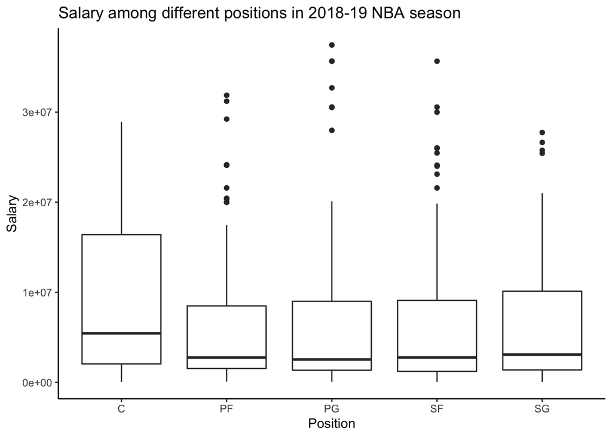

```r
#boxplot of salary in each positions
p1 <- players %>%
  filter(Pos %in% c("PG", "SG", "SF", "PF", "C")) %>%
  ggplot(aes(x=Pos, y=salary)) +
  geom_boxplot() +
  labs(x="Position", y="Salary",
       title="Salary among different positions in 2018-19 NBA season") +
  theme_classic()
p1
```

In order to optimize the cost associated with a trade, it is necessary to conduct a thorough investigation of the current squad and have a better understanding of the current team.

According to the data below, there are 20 players listed as Chicago Bulls players. This exceeds the limitation of 15 players on its roster. Additionally, the player with the highest salary on the roster is Otto Porter, who earns $26,011,913. He plays in the small forward position. In this case, Otto is not performing impressive data like his salary, so he could be cut from the current team. Meanwhile, Zach LaVine is the highest playing time on court, which means he is the current star player for Chicago Bulls.

```r
#count the current roaster number
player_chi <- players %>%
  filter(Tm %in% c("CHI")) %>%
  filter(Pos %in% c("PG", "SG", "SF", "PF", "C"))
paste0("Currently there are ",count(player_chi), " players in Chicago Bulls roaster.")
```

```
## [1] "Currently there are 20 players in Chicago Bulls roaster."
```

```r
temp_index <- grep(max(player_chi$salary), player_chi$salary)
max_name <- player_chi[temp_index,]$player_name
max_salary <- player_chi[temp_index,]$salary
max_pos <- player_chi[temp_index,]$Pos
paste0("The most expensive player on the roaster is ", max_name, " with a salary of ", max_salary, ". His position is ", max_pos, ".")
```

```
## [1] "The most expensive player on the roaster is Otto Porter with a salary of 26011913. His position is SF."
```

```r
temp_index <- grep(max(player_chi$MP), player_chi$MP)
max_time_name <- player_chi[temp_index,]$player_name
paste0("The player with the most minutes played is ", max_time_name, ".")
```

```
## [1] "The player with the most minutes played is Zach LaVine."
```

#### Relationships between variables

This section will explore the relationship between the variables chose and explained in the introduction for each position. It shall help to identify potential causal relationships between variables, to develop better models and make better predictions.

- Point Guard

  Assists (AST), steals (STL), turnovers (TOV), 3-points percentages (X3P.) are considered as key indicators for assessing point guard’s performance and effectiveness. A high number of assists indicates that the point guard is effectively creating scoring opportunities for their teammates. A high number of steals and turnovers indicates that the point guard has excellent abilities to disrupt the opposing team’s offensive flow and lead to scoring opportunities. A high 3-point percentage indicates that the point guard is a skilled long-range shooter and effectively winning points from the perimeter.

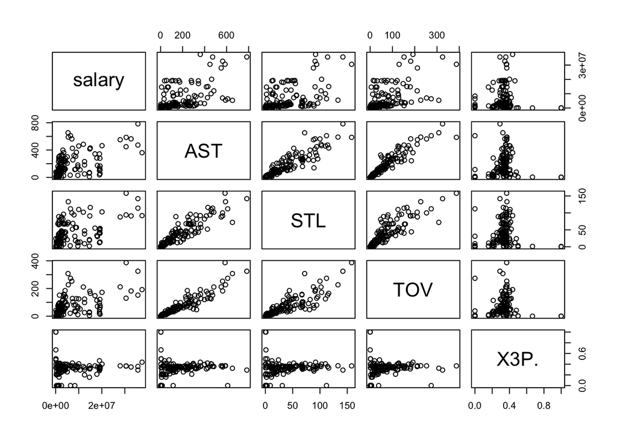

```r
# filter all point guard players and make a new df
pg <- players %>%
  filter(Pos %in% "PG")

# plot relationships
pairs(formula = ~salary + AST + STL + TOV + `X3P.`, data=pg)
```

Based on the plot, it appears that there is some degree of association between salary and the chosen variables. Furthermore, assists, steals, and turnovers demonstrate a strong correlation, which is likely due to their significance in evaluating a point guard’s performance. It is possible that players who struggle in one area may struggle in others as well.

- Shooting Guard

  Field goal percentage (FG.), three-point percentage (X3P.), free throw percentage (FT.), effective field goal percentage (eFG.) are identified as important metrics to measure the ability of a shooting guard. All the chosen variables are related to goal winning percentage, which means the shooting guard is able to consistently make shots.

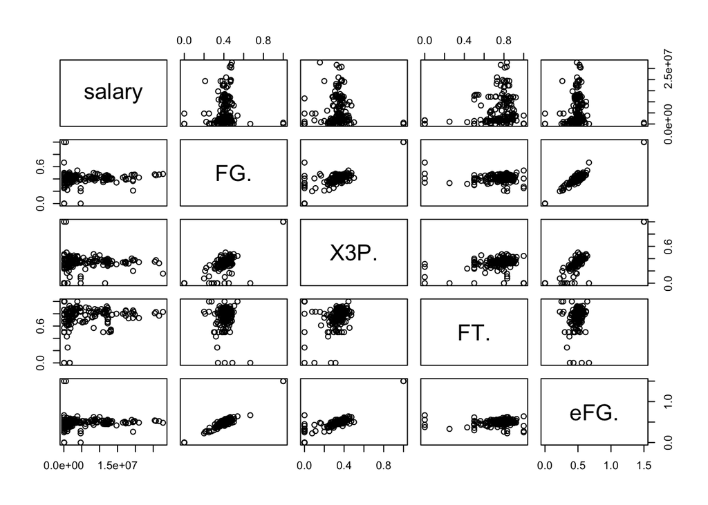

```r
# filter all shooting guard players and make a new df
sg <- players %>%
  filter(Pos %in% "SG")

# plot relationships
pairs(formula = ~salary + FG. + X3P. + FT. + eFG., data=sg)
```

- Small Forward

  Two-points field goal percentage (X2P.), total rebounds (TRB), and steals (STL) are essential to measuring small forwars. Small forwards are expected to score from inside the paint and mid-range areas, creating 2-point field goals, hence, 2-point percentage is an important indicator to reflect their scoring efficiency and effectiveness. Meanwhile, as a all-round player on the court, small forward should contribute on both offense and defense, therefore, a high total rebounds and steals indicates that the player is active and engaged in the game, which leads to team success.

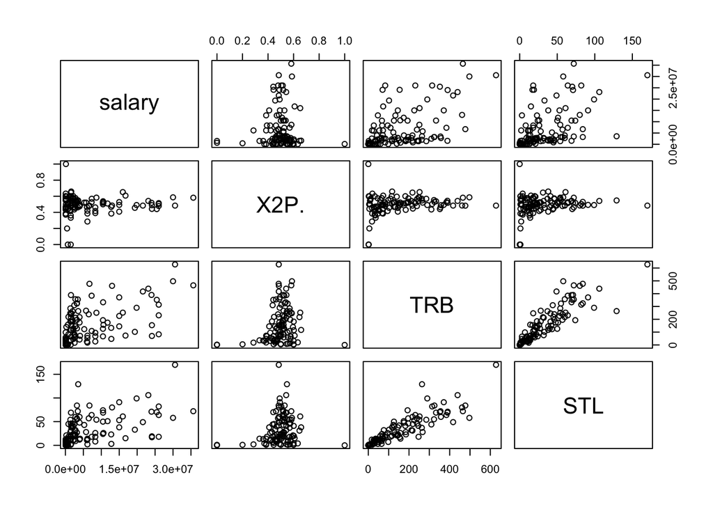

```r
# filter all small forward players and make a new df
sf <- players %>%
  filter(Pos %in% "SF")

# plot relationships
pairs(formula = ~salary + X2P. + TRB + STL, data=sf)
```

- Power Forward

  Offensive rebounds (ORB), defensive rebounds (DRB), blocks (BLK) are important indicators of a power forward’s effectiveness on the court. Offensive rebounds indicate a power forward’s ability to grab a missed shot by their team and give them another chance to score, while defensive rebounds show their ability to prevent the opposing team from getting an offensive rebound and creating more scoring opportunities. Additionally, blocks are an important statistic for power forwards because they demonstrate the ability to defend the rim and protect the basket from scoring attempts by the opposing team. These data reflects a power forward’s defensive ability, which is critical to assess the effectiveness of a power forward on the court.

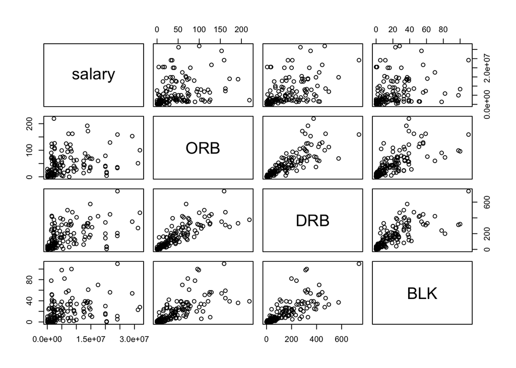

```r
# filter all power forward players and make a new df
pf <- players %>%
  filter(Pos %in% "PF")

# plot relationships
pairs(formula = ~salary + ORB + DRB + BLK, data=pf)
```

The plot demonstrate the relationship between each variables. It is evident that there is a positive correlation between salary, offensive rebounds (ORB), defensive rebounds (DRB), and blocks (BLK). It is crucial to note that a strong correlation between predictors can negatively affect the model’s performance. Hence, the model should be proceed carefully with the issue of multicollinearity.

- Center

  Total rebounds (TRB), blocks (BLK) and 2-points goal percentage (X2P.) are identified as key measurements for center players. A high total rebounds number and blocks indicates that the player can control the paint and good at defending the basket. Additionally, centers typcally score points in the paint by dunking, layups, or hook shots, therefore, the center’s ability to score efficiently from inside the paint is reflected in their two-point field goal percentage.

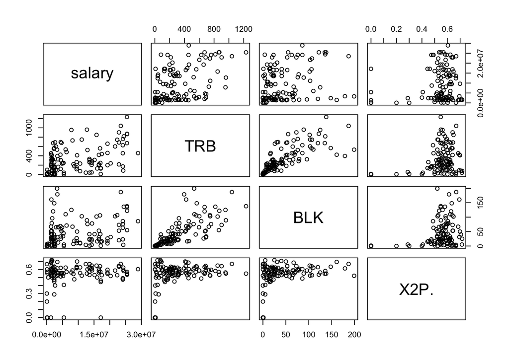

```r
# filter all center players and make a new df
cc <- players %>%
  filter(Pos %in% "C")

# plot relationships
pairs(formula = ~salary + TRB + BLK + X2P., data=cc)
```

The plot provides an insightful view of the relationship between the variables salary, total rebounds (TRB), blocks (BLK) and 2-points goal percentage (X2P.). As stated previously, TRB and BLK are highly correlated, as they both measure a player’s defensive capabilities. A player who excels in defensive performance is likely to receive a higher salary. Additionally, the plot reveals some outliers, particularly in the relationship between salary and 2-points goal percentage.

## 4. Data modelling and results

This section will build models for each position, evaluate assumptions and analyse the results.

#### Point Guard

```r
# build model for point guard
model_pg <- lm(salary ~ AST + STL + TOV + `X3P.`, data=pg)
tidy(model_pg, conf.int=TRUE)
```

```
## # A tibble: 5 × 7
##   term        estimate std.error statistic p.value  conf.low conf.high
##   <chr>          <dbl>     <dbl>     <dbl>   <dbl>     <dbl>     <dbl>
## 1 (Intercept) 1635138.  1710949.    0.956    0.341 -1751044.  5021319.
## 2 AST           12179.    12501.    0.974    0.332   -12562.    36921.
## 3 STL           27508.    41335.    0.665    0.507   -54299.   109316.
## 4 TOV           25866.    23965.    1.08     0.283   -21564.    73295.
## 5 X3P.        -271069.  4590036.   -0.0591   0.953 -9355321.  8813182.
```

The linear regression model was built based on the response variable salary and predict variables assist (AST), steals (STL), turnovers (TOV) and 3-point field goal percentage (X3P.). This model provides the equation: `salary = 1635137.63 + 12179.31 * AST + 27508.10 * STL + 25865.68 * TOV - 271069.47 * X3P.`

Although this is unlikely to happen in real life in a team, the model indicates that even with 0 assist, 0 steals, 0 turnovers, and 0 three-point field goal percentage, a point guard player could still receive a minimum salary of 1,635,137.63 dollars. Additionally, for every additional unit of AST, salary is estimated to increase by $12,179.31, holding all other predictors constant. Similar to other predict variables. It is also worth mention that the P-value for selected variables are not significant (higher than 0.05), which indicates statistically these variables do not have a significant impact on determining a point guard’s salary.

```r
# check variance inflation factor
sqrt(car::vif(model_pg))
```

```
##      AST      STL      TOV     X3P.
## 3.377855 2.336505 2.771437 1.004500
```

```r
#none with a VIF value above 5
```

```r
# predict salary for pg
pg <- mutate(pg, exp_salary = predict(model_pg, newdata=pg))
```

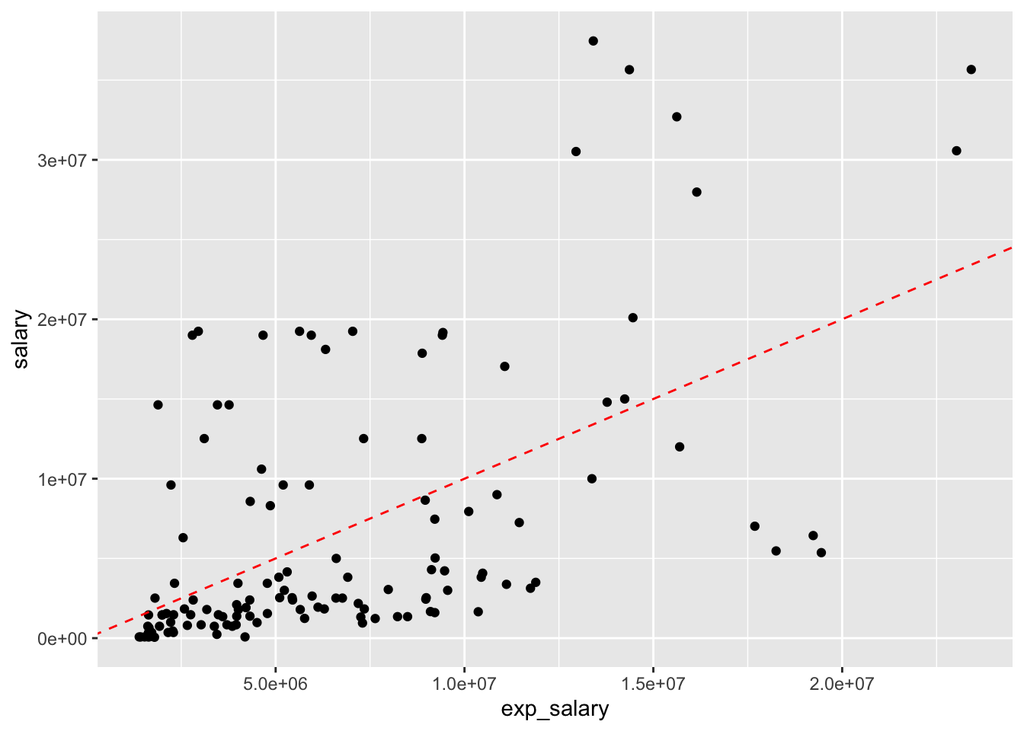

```r
# plot the predicted value against actual value
ggplot(pg, aes(x=exp_salary, y=salary)) +
  geom_point() +
  geom_abline(linetype="dashed", colour="red")
```

#### Shooting Guard

```r
# build model for shooting guard
model_sg <- lm(salary ~ FG. + X3P. + FT. + eFG., data=sg)
tidy(model_sg, conf.int=TRUE)
```

```
## # A tibble: 5 × 7
##   term          estimate std.error statistic p.value   conf.low conf.high
##   <chr>            <dbl>     <dbl>     <dbl>   <dbl>      <dbl>     <dbl>
## 1 (Intercept)  -3297710.  4486715.    -0.735  0.463  -12160263.  5564842.
## 2 FG.          36856597. 20743556.     1.78   0.0776  -4117891. 77831084.
## 3 X3P.          9498467.  8789282.     1.08   0.282   -7862892. 26859825.
## 4 FT.           6840098.  3155772.     2.17   0.0317    606541. 13073655.
## 5 eFG.        -28110171. 20711663.    -1.36   0.177  -69021661. 12801319.
```

The linear regression model was built based on the response variable salary and predict variables field goals (FG), 3-point field goal percentage (X3P.), free throw (FT), effective field goal percentage (eFG). This model provides the equation: `salary = -3297710 + 36856597 * FG + 9498467 * X3P + 6840098 * FT - 28110171 * eFG.`

```r
# check variance inflation factor
sqrt(car::vif(model_sg))
```

```
##      FG.     X3P.      FT.     eFG.
## 2.298758 1.650985 1.069242 2.887425
```

```r
#none with a VIF value above 5
```

```r
# predict salary for sg
sg <- mutate(sg, exp_salary = predict(model_sg, newdata=sg))
```

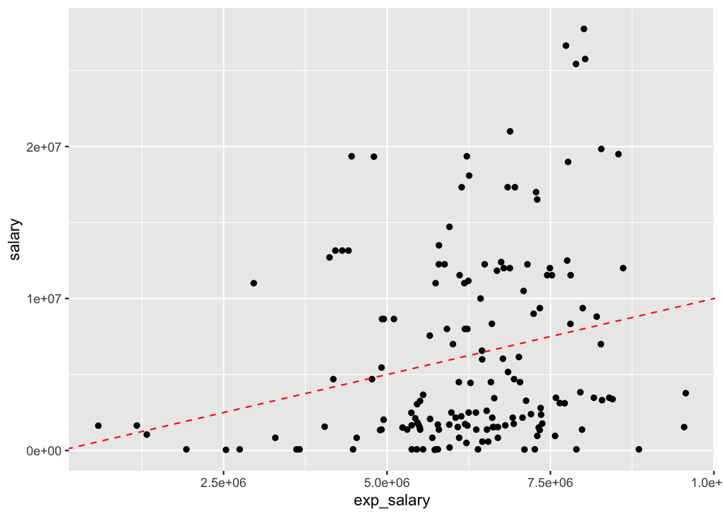

```r
# plot the predicted value against actual value
ggplot(sg, aes(x=exp_salary, y=salary)) +
  geom_point() +
  geom_abline(linetype="dashed", colour="red")
```

#### Small Forward

```r
# build model for small forward
model_sf <- lm(salary ~ X2P. + TRB + STL, data=sf)
tidy(model_sf, conf.int=TRUE)
```

```
## # A tibble: 4 × 7
##   term         estimate std.error statistic p.value   conf.low conf.high
##   <chr>           <dbl>     <dbl>     <dbl>   <dbl>      <dbl>     <dbl>
## 1 (Intercept)  4270006.  3139050.     1.36   0.177   -1954150. 10494163.
## 2 X2P.        -6119055.  6257274.    -0.978  0.330  -18526073.  6287963.
## 3 TRB            21121.    10232.     2.06   0.0415       832.    41409.
## 4 STL            64035.    45783.     1.40   0.165     -26743.   154814.
```

The linear regression model was built based on the response variable salary and predict variables 2-points goal percentage (X2P.), total rebounds (TRB) and steals (STL). This model provides the equation: `salary = 4270006.42 - 6119055.25 * X2P + 21120.79 * TRB + 64035.38 * STL.`

```r
# check variance inflation factor
sqrt(car::vif(model_sf))
```

```
##     X2P.      TRB      STL
## 1.020697 2.077840 2.063412
```

```r
#none with a VIF value above 5
```

```r
# predict salary for sf
sf <- mutate(sf, exp_salary = predict(model_sf, newdata=sf))
```

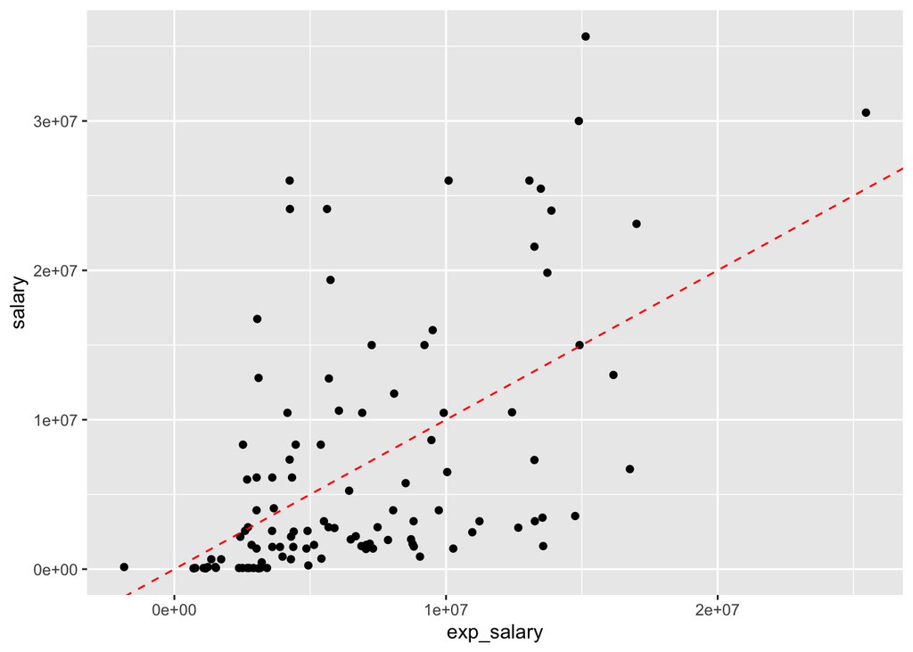

```r
# plot the predicted value against actual value
ggplot(sf, aes(x=exp_salary, y=salary)) +
  geom_point() +
  geom_abline(linetype="dashed", colour="red")
```

#### Power Forward

```r
# build model for power forward
model_pf <- lm(salary ~ ORB + DRB + BLK, data=pf)
tidy(model_pf, conf.int=TRUE)
```

```
## # A tibble: 4 × 7
##   term        estimate std.error statistic     p.value conf.low conf.high
##   <chr>          <dbl>     <dbl>     <dbl>       <dbl>    <dbl>     <dbl>
## 1 (Intercept) 2523692.   755880.     3.34  0.00108     1029184.  4018201.
## 2 ORB          -25837.    20336.    -1.27  0.206        -66046.    14372.
## 3 DRB           34776.     6788.     5.12  0.000000984   21355.    48197.
## 4 BLK          -30824.    37377.    -0.825 0.411       -104726.    43078.
```

The linear regression model was built based on the response variable salary and predict variables offensive rebounds (ORB), defensive rebounds (DRB) and blocks (BLK). This model provides the equation: `salary = 2523692.24 - 25836.84 * ORB + 34776.27 * DRB - 30824.06 * BLK.`

```r
# check variance inflation factor
sqrt(car::vif(model_pf))
```

```
##      ORB      DRB      BLK
## 1.794882 1.936243 1.568773
```

```r
#none with a VIF value above 5
```

```r
# predict salary for pf
pf <- mutate(pf, exp_salary = predict(model_pf, newdata=pf))
```

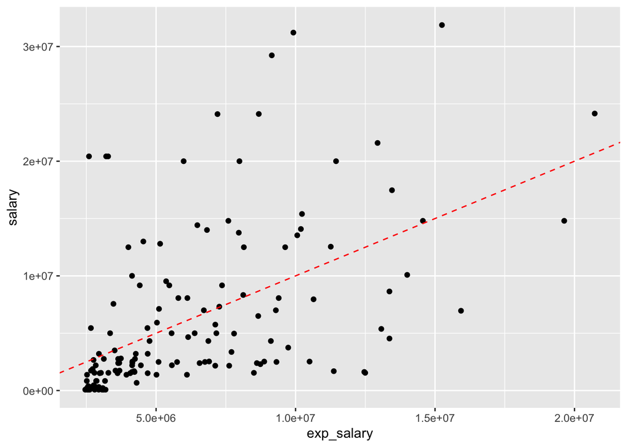

```r
# plot the predicted value against actual value
ggplot(pf, aes(x=exp_salary, y=salary)) +
  geom_point() +
  geom_abline(linetype="dashed", colour="red")
```

#### Center

```r
# build model for power forward
model_cc <- lm(salary ~ TRB + BLK + X2P., data=cc)
tidy(model_cc, conf.int=TRUE)
```

```
## # A tibble: 4 × 7
##   term        estimate std.error statistic    p.value  conf.low conf.high
##   <chr>          <dbl>     <dbl>     <dbl>      <dbl>     <dbl>     <dbl>
## 1 (Intercept) 4654589.  2745225.    1.70   0.0927      -783680. 10092858.
## 2 TRB           19395.     3817.    5.08   0.00000148    11833.    26956.
## 3 BLK          -40863.    23283.   -1.76   0.0819       -86988.     5261.
## 4 X2P.         454057.  5140543.    0.0883 0.930      -9729320. 10637433.
```

The linear regression model was built based on the response variable salary and predict variables total rebounds (TRB), blocks (BLK), and 2-points goal percentage (X2P.). This model provides the equation: `salary = 4654588.68 + 19394.64 * TRB - 40863.48 * BLK + 454056.68 * X2P.`

```r
# check variance inflation factor
sqrt(car::vif(model_cc))
```

```
##      TRB      BLK     X2P.
## 1.554541 1.550348 1.053183
```

```r
#none with a VIF value above 5
```

```r
# predict salary for center
cc <- mutate(cc, exp_salary = predict(model_cc, newdata=cc))
```

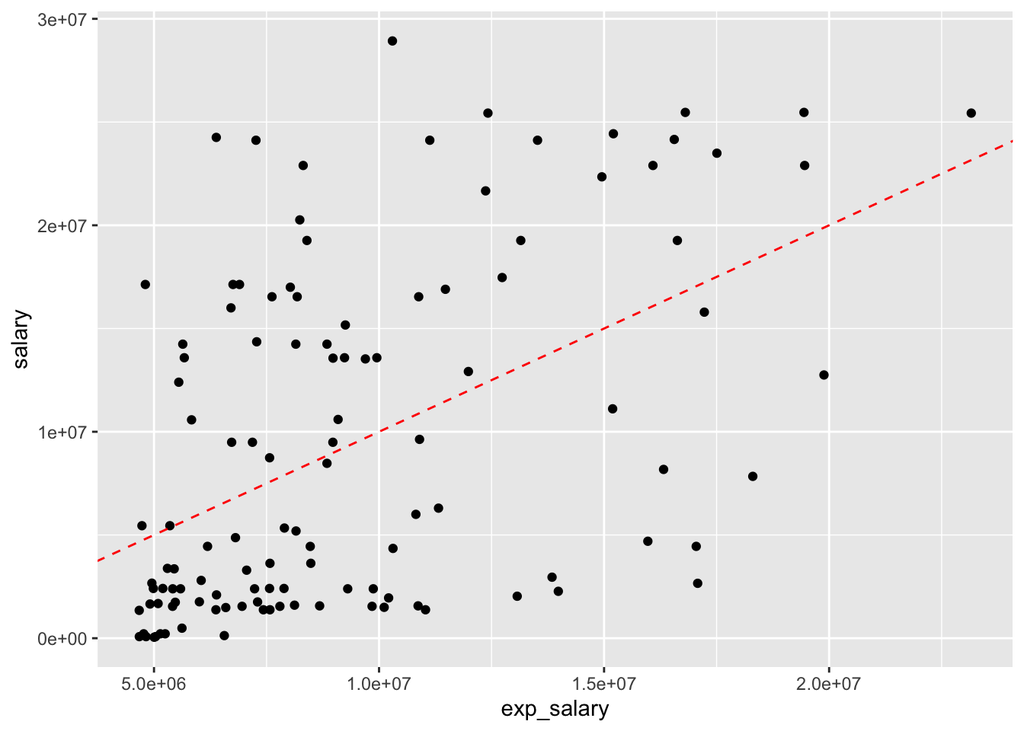

```r
# plot the predicted value against actual value
ggplot(cc, aes(x=exp_salary, y=salary)) +
  geom_point() +
  geom_abline(linetype="dashed", colour="red")
```

#### Assumptions

The response variable `salary` is continuous because it can take on any value within a range. All the predict variables are continuous, as they are either ratio or interval scale. The observations of players across the NBA league are independent of each other. As tested before, there are linear relationships between salary and each explanatory variable. There appear to be some outliers or high leverage points in the data; however, it is possible to provide justifiable reasons for their presence. According to the variance inflation factor values, calculated in each section, none of them were above 5, which means there is no significant multicollinearity.

## 5. Player recommendations

**Point guard**

```r
# point guard
pg %>%
  select(player_name, exp_salary, salary, Age, Tm, MP, PTS) %>%
  arrange(exp_salary) %>%
  top_n(20)
```

```
##          player_name exp_salary   salary Age  Tm   MP  PTS
## 1       Derrick Rose    7188027  2176260  30 MIN 1392  917
## 2  Spencer Dinwiddie   10364002  1656092  25 BRK 1914 1143
## 3      Collin Sexton   10481247  4073760  20 CLE 2605 1371
## 4     Reggie Jackson   11065861 17043478  28 DET 2289 1260
## 5        DJ Augustin   11450631  7250000  31 ORL 2269  948
## 6       Jamal Murray   11886564  3499800  21 DEN 2447 1367
## 7        Mike Conley   12953278 30521115  31 MEM 2342 1478
## 8      Stephen Curry   13410366 37457154  30 GSW 2331 1881
## 9       Eric Bledsoe   14241835 15000000  29 MIL 2272 1241
## 10        Chris Paul   14366415 35654150  33 HOU 1857  906
## 11      Kyrie Irving   14459869 20099189  26 BOS 2214 1596
## 12        Kyle Lowry   15620998 32700000  32 TOR 2213  926
## 13      Kemba Walker   15696907 12000000  28 CHO 2863 2102
## 14    Damian Lillard   16150149 27977689  28 POR 2838 2067
## 15  D'Angelo Russell   17686891  7019698  22 BRK 2448 1712
## 16      De'Aaron Fox   18250450  5470920  21 SAC 2546 1399
## 17       Ben Simmons   19232619  6434520  22 PHI 2700 1337
## 18        Trae Young   19447612  5363280  20 ATL 2503 1549
## 19      James Harden   23028756 30570000  29 HOU 2867 2818
## 20 Russell Westbrook   23417602 35665000  30 OKC 2630 1675
```

James Harden could be Chicago Bulls next starting point guard. He is currently playing in Houston Rockets, with the highest total points win on the list. The expected salary for him is $23,028,756, and his current salary is $30,570,000. Harden is a famous player in the NBA, known for his signature step-back jump shot. This could bring experience to the team. On the other hand, youngsters such as Jamal Murray, Trae Young should be recruited, as they have the potential to shoot or create chances for the team. Jamal Murray has an expected salary at $11,886,564, but his current salary is $3,499,800; similarly, Trae Young has an expected salary at $19,447,612, but his current salary is $5,363,280.

```r
# save the recommendation players in a new df
recommendation <- pg %>%
filter(player_name %in% c("James Harden", "Jamal Murray", "Trae Young"))
```

**Shooting guard**

```r
# shooting guard
sg %>%
  select(player_name, exp_salary, salary, Age, Tm, MP, PTS) %>%
  arrange(exp_salary) %>%
  top_n(20)
```

```
##         player_name exp_salary   salary Age  Tm   MP  PTS
## 1       Eric Gordon    5794043 13500375  30 HOU 2158 1103
## 2       Luka Doncic    6452290  6569040  19 DAL 2318 1526
## 3      Tim Hardaway    6844712 17325000  26 TOT 2057 1174
## 4     Terrence Ross    7089080 10500000  27 ORL 2150 1223
## 5         JJ Redick    7147766 12250000  34 PHI 2379 1372
## 6       Dwyane Wade    7201818  2393887  37 MIA 1885 1083
## 7     Evan Fournier    7280000 17000000  26 ORL 2553 1226
## 8   Josh Richardson    7337280  9367200  25 MIA 2539 1209
## 9  Donovan Mitchell    7717589  3111480  22 UTA 2598 1829
## 10     Jrue Holiday    7737181 26641111  28 NOP 2402 1420
## 11  Jordan Clarkson    7756514 12500000  26 CLE 2214 1364
## 12    Klay Thompson    7769299 18988725  28 GSW 2652 1680
## 13       Joe Harris    7805096  8333333  27 BRK 2293 1041
## 14     Bradley Beal    7890442 25434262  25 WAS 3028 2099
## 15      Buddy Hield    7957087  3833760  26 SAC 2615 1695
## 16    DeMar DeRozan    8012142 27739975  29 SAS 2688 1635
## 17      CJ McCollum    8030934 25759766  27 POR 2375 1468
## 18      Jeremy Lamb    8271690  7000000  26 CHO 2250 1208
## 19     Devin Booker    8288946  3314365  22 PHO 2242 1700
## 20      Zach LaVine    8540420 19500000  23 CHI 2171 1492
```

Donovan Mitchell could be the starting shooting guard for the next season, while considering Buddy Hield, Devin Booker as bench players. Donovan Mitchell is a young player who is currently plays for Utah Jazz. Mitchell is a shooting guard with a relevantly high total points, which makes him one of the most promising young stars in the NBA. He shall have an expected salary at $7,717,589, however, his current salary is at $3,111,480. Similarly, Buddy Hield and Devin Booker are also young players who have demonstrated promising statistics and command a relatively low salary. This makes them ideal candidates for recruitment as bench players.

```r
temp_df <- sg %>%
filter(player_name %in% c("Donovan Mitchell", "Buddy Hield", "Devin Booker"))
recommendation <- rbind(recommendation, temp_df)
```

**Small forward**

```r
# small forward
sf %>%
  select(player_name, exp_salary, salary, Age, Tm, MP, PTS) %>%
  arrange(exp_salary) %>%
  top_n(20)
```

```
##         player_name exp_salary   salary Age  Tm   MP  PTS
## 1         TJ Warren    8090111 11750000  25 PHO 1360  772
## 2    Brandon Ingram    8514221  5757120  21 LAL 1760  950
## 3  Bojan Bogdanovic   12429620 10500000  29 IND 2573 1454
## 4        Cedi Osman   12660035  2775000  23 CLE 2444  991
## 5       Otto Porter   13068833 26011913  25 TOT 1683  780
## 6  Danilo Gallinari   13253488 21587579  30 LAC 2059 1346
## 7       Jae Crowder   13253914  7305825  28 UTA 2166  951
## 8       Kelly Oubre   13270137  3208630  23 TOT 1935 1047
## 9    Andrew Wiggins   13488499 25467250  23 MIN 2543 1321
## 10  Justise Winslow   13551432  3448926  22 MIA 1959  830
## 11     Jimmy Butler   13730083 19841627  29 PHI 1824 1002
## 12    Nicolas Batum   13877838 24000000  30 CHO 2354  699
## 13    Mikal Bridges   14753218  3557400  22 PHO 2417  684
## 14     Kevin Durant   14889208 30000000  30 GSW 2702 2027
## 15     Trevor Ariza   14916346 15000000  33 TOT 2349  863
## 16     LeBron James   15140433 35654150  34 LAL 1937 1505
## 17  Khris Middleton   16161781 13000000  27 MIL 2393 1407
## 18     Jayson Tatum   16768093  6700800  20 BOS 2455 1243
## 19    Kawhi Leonard   17013257 23114066  27 TOR 2040 1596
## 20      Paul George   25458257 30560700  28 OKC 2841 2159
```

Bojan Bogdanovic shall be picked as the one of the starting 5 players for Chicago Bulls, while Brandon Ingram and Jayson Tatum shall serve as bench players. Bogdanovic is an experienced small forward from indiana pacers. Bogdanovic has an outstanding scoring ability, with a 53.8% two-points field goal percentage throughout the 2018-19 NBA season. His expected salary will be $12,429,620 and actual salary is $10,500,000. Additionally, raising star Brandon Ingram and Jayson Tatum have shown remarkable all-round stats in the past season, making them a potential valuable asset to Chicago Bulls.

```r
temp_df <- sf %>%
  filter(player_name %in% c("Bojan Bogdanovic", "Jayson Tatum", "Brandon Ingram"))
recommendation <- rbind(recommendation, temp_df)
```

**Power forward**

```r
# power forward
pf %>%
  select(player_name, exp_salary, salary, Age, Tm, MP, TRB) %>%
  arrange(exp_salary) %>%
  top_n(20)
```

```
##              player_name exp_salary   salary Age  Tm   MP TRB
## 1             Taj Gibson    6823630 14000000  33 MIN 1686 458
## 2          Marvin Bagley    7265371  7314960  19 SAC 1567 471
## 3         Thaddeus Young    7964297 13764045  30 IND 2489 523
## 4        Nemanja Bjelica    8661569  6500000  30 SAC 1788 444
## 5           John Collins    8739163  2299080  21 ATL 1829 595
## 6           Paul Millsap    9147403 29230769  33 DEN 1895 505
## 7            Dario Saric   10501779  2526840  24 TOT 2023 457
## 8              PJ Tucker   10645200  7959537  33 HOU 2802 479
## 9            Noah Vonleh   12464254  1621415  23 NYK 1722 528
## 10         Pascal Siakam   12496987  1544951  24 TOR 2548 549
## 11          Aaron Gordon   12940032 21590909  23 ORL 2633 574
## 12         Marcus Morris   13074026  5375000  29 BOS 2091 458
## 13         Julius Randle   13365440  8641000  24 NOP 2232 634
## 14       Lauri Markkanen   13365975  4536120  21 CHI 1682 470
## 15        Draymond Green   13456607 17469565  28 GSW 2065 481
## 16              Rudy Gay   14001895 10087200  32 SAS 1842 470
## 17         Blake Griffin   15247900 31873932  29 DET 2622 565
## 18       Al-Farouq Aminu   15931354  6957105  28 POR 2292 610
## 19         Tobias Harris   19631591 14800000  26 TOT 2847 645
## 20 Giannis Antetokounmpo   20724651 24157304  24 MIL 2358 898
```

```r
temp_df <- pf %>%
  filter(player_name %in% c("Al-Farouq Aminu", "John Collins", "Pascal Siakam"))
recommendation <- rbind(recommendation, temp_df)
```

**Center**

```r
# center
cc %>%
  select(player_name, exp_salary, salary, Age, Tm, MP, TRB) %>%
  arrange(exp_salary) %>%
  top_n(20)
```

```
##            player_name exp_salary   salary Age  Tm   MP  TRB
## 1        Anthony Davis   12419584 25434263  25 NOP 1850  672
## 2        Jarrett Allen   13069769  2034120  20 BRK 2096  672
## 3    LaMarcus Aldridge   14951549 22347015  33 SAS 2687  744
## 4         Jusuf Nurkic   15190311 11111111  24 POR 1974  748
## 5     Hassan Whiteside   15206381 24434262  29 MIA 1674  817
## 6  Willie Cauley-Stein   15972571  4696874  25 SAC 2213  678
## 7       DeAndre Jordan   16085958 22897200  30 DAL 1554  686
## 8        Deandre Ayton   16322412  8175840  20 PHO 2183  729
## 9         Steven Adams   16559507 24157304  25 OKC 2669  760
## 10         Enes Kanter   16628384 19264603  26 TOT 1640  659
## 11         Joel Embiid   16804894 25467250  24 PHI 2154  871
## 12            Ed Davis   17047488  4449000  29 BRK 1446  694
## 13    Domantas Sabonis   17079786  2659800  22 IND 1838  690
## 14        Clint Capela   17227395 15793104  24 HOU 2249  848
## 15         Rudy Gobert   17506700 23491573  26 UTA 2577 1041
## 16  Karl-Anthony Towns   18304318  7839435  23 MIN 2545  954
## 17        Nikola Jokic   19441817 25467250  23 DEN 2504  865
## 18      DeAndre Jordan   19456568 22897200  30 TOT 2047  902
## 19      Nikola Vucevic   19885868 12750000  28 ORL 2510  960
## 20      Andre Drummond   23158445 25434262  25 DET 2647 1232
```

Andre Drummond shall be considered as the starting center for Chicago Bulls, as he has an outstanding defensive statistics. Drummond has the highest total rebounds on the list above, which makes him a solid consistent player in the NBA. He has an expected salary at $23,158,445, but his actual salary is a bit higher, with a number of $25,434,262. Meanwhile, Jarrett Allen and Domantas Sabonis should be recruited as bench players, as they are showing promising defensive statistics at a young age.

```r
temp_df <- cc %>%
  filter(player_name %in% c("Andre Drummond", "Jarrett Allen", "Domantas Sabonis"))
recommendation <- rbind(recommendation, temp_df)
```

The total cost of the Chicago Bulls roster is $113,579,923, which is below the salary cap of $118,000,000. This provides the team with the opportunity to allocate the remaining funds towards recruiting new players for off-season play-offs and training.

```r
recommendation <- recommendation[!duplicated(recommendation$player_name), ]
sum(recommendation$salary)
```

```
## [1] 113579923
```

```r
#save roster into csv
write.csv(players, "project-data/processed/roster.csv", row.names = FALSE)
```

## 6. Summary

#### Key Findings

There are a total number of 15 players on the recommendation list for Chicago Bulls for the next season. Three players were identified and selected in each position based on their performance. The models are built separately for each position, so they can have separate key indicators to identify talent players. Most of the well-known players are overpaid, according to the predicted salaries. Because of the low salary cap, it is unrealistic for Chicago Bulls to sign well-performed star players for all 5 positions. On the other hand, the average age of the recommend roster is 23.3. Young players are more suitable for Chicago Bulls. Most of them are having a promised future if they keep consistent statistics. This could benefit the club by investing on these young players. Finally, a well-structured team consists with experience players and youngsters could establish the foundation of the team and potentially lead to success.

#### Limitation

While this model can provide valuable insights into potential valuable players for the next season and provide ideas for how teams should approach signings, it is important to acknowledge that the model still has limitations. One of the limitations is the presence of outliers in the data. For instance, some players may have high salaries despite poor performance. This could be due to insufficient data collected, as some players may have missed games due to injuries. This could negatively affect the accuracy of the prediction. Furthermore, some players may have mediocre data, but possess outstanding skills that may be beneficial to a team. However, such skills may not be noticeable in the model. This could lead to missed opportunities for teams to acquire players that are a good fit for their needs. Moreover, signing players may come with additional expenses such as associate fees, which could cause a team’s budget to be insufficient. This may limit their ability to acquire the best players available. Finally, team tactics are not always fixed. The tactics of a new season may not align with the team’s tactics at the time of signings, which could result in players not performing well after being signed. This could lead to significant losses for the team. Therefore, it is important for teams to carefully consider all factors before making any signings based solely on the model’s predictions.

#### Conclusion

A roster with 5 staring players and 10 substitutions were identified in the recommendation list. Finalizing this roster for the NBA’s upcoming 2019-2020 season could potentially cost the Chicago Bulls a total of $113,579,923. The selection of players was based on a modeling approach that utilized key basketball indicators. However, this report has its limitations, such as player skills specialisation, insufficient data collection, or trading difficulties. Thus, it is important for Chicago Bulls to thoughfully consider all factors and risks before making any decisions based solely on the recommendation list.

## 7. Reference list

1. Haefner J. 7 ways to make a better point guard [Internet]. 2011 [cited 2023 May 7]. Available from: https://www.usab.com/youth/news/2011/06/7ways-to-make-a-better-point-guard.aspx#:~:text=Point%20guard%20is%20perhaps%20the,against%20the%20opposing%20point%20guard.
2. The ultimate guide to playing small forward [Internet]. 2015 [cited 2023 May 8]. Available from: https://www.usab.com/youth/news/2011/06/the-ultimate-guide-to-playing-small-forward.aspx
3. The ultimate guide to playing power forward [Internet]. 2015 [cited 2023 May 8]. Available from: https://www.usab.com/youth/news/2011/06/the-ultimate-guide-to-playing-power-forward.aspx
4. How many players on a basketball team? (roster size) [Internet]. 2023 [cited 2023 May 8]. Available from: https://www.gaimday.com/blog/players-basketball-team/